# Assignment 1

## Getting started with SED fitting & error estimation

**Completed By**: Justin Marchioni

**Date**: Feb. 12$^\textrm{th}$, 2024

This assignment is split into 3 sections, roughly corresponding to the contents of each of the 3 weeks in the Error Estimation module.

The SETUP section is designed to be done first, to familarize yourself with the data and the details of SED fitting. Section 1 is shorter to account for this. You should be able to finish Section 1 after January 26th, Section 2 after February 2nd, and Section 3 after February 9th. You can work on this assignment during the lab hours, as well as in your own time - and feel free to ask the instructors questions!

All assignments are presented as Jupyter notebooks. You will fork the repository to have your own access to all files. You can edit this notebook directly with your answers and push your changes to GitHub. Feel free to write any commonly used functions in a separate module and import them here if you like.

# Section 0

## Setup

First, we need to set up the SED fitting project, install Prospector, and make sure we can run Prospector. This section is written assuming that you are using a Unix-based system (including MacOS). If you are using Windows, consider installing and using [Windows Subsystem for Linux, or WSL](https://learn.microsoft.com/en-us/training/modules/wsl-introduction/).

1. Download the data from [here](https://irfu.cea.fr/Pisp/yu-yen.chang/sw.html) (both the input and output catalog).  
   The data comes from [Chang et al. (2015)](https://ui.adsabs.harvard.edu/abs/2015ApJS..219....8C/abstract), who used MAGPHYS (another SED fitting code) to fit the photometry stored in the input file and obtain stellar masses / ages / etc. stored in the output file.

   > Be careful of where you store these files. If you store them in a random place in this repository, they will get pushed to Git alongside your changes. The files are heavy, which will cause problems downstream. We suggest placing your files in `projects/sed-fitting/data` folder (for Chang catalogs) and `projects/sed-fitting/output` folder (for your own Prospector output files). These folders are added in the `.gitignore` file in the root, and so anything in these folders will be ignored by Git.
2. Install [Prospector](https://github.com/bd-j/prospector)

   > We found this easiest to do using the [conda script](https://github.com/bd-j/prospector/blob/main/conda_install.sh) provided: download the script somewhere on your PC and run `bash conda_install.sh`. Again, best not to do this inside the Git repository as the bash script will download several large libraries. If you are feeling brave, you can try doing it from this repository, but first make sure to add the libraries to `.gitignore`.  
   > Make sure to follow the instructions from `conda_install.sh`: add SPS_HOME to your `~/.bashrc` file as your terminal says. If you are a MacOS user, instead set the SPS_HOME in your `~/.zshrc` file, or whichever shell initialization file you think your system uses.  
   > This bash script will create a new conda environment, `prospector`, which you can run using `conda activate prospector`.
3. Fix a Prospector + NumPy >= 1.20 issue (you might not need this)  
   Run the following cell:

```python
import numpy as np
print(np.__version__)
```

```
1.26.3
```

If the version is greater than 1.20.0, you will need to fix a library in Prospector to make it compatible with a later NumPy. There is a file `write_results.py` in the project library. Copy it to your Prospector installation location within your conda environment, it should be something like `/home/[username]/[your conda installation]/envs/prospector/lib/[your python version]/site-packages/prospect/io`

4. Install any other Python libraries  
   Since we have made a new environment, it will only have prospector and its dependancies installed. We still need to install other useful Python libraries in the new environment.

   > We listed the libraries you will need in `requirements.txt`.  
   > First, run `conda activate prospector` to make sure you are using the new environment.  
   > Then, you can install all required libraries simply using `pip install -r requirements.txt`

## Test Prospector

We have provided a notebook, Prospector Example, that gives step-by-step instructions for loading in the photometric data for one galaxy and running Prospector to get a simple fit to that galaxy's SED. If you have any questions, you can either ask us, or consult the [Prospector documentation](https://prospect.readthedocs.io/en/latest/) that has explanations of all the different parameters, models, and use cases.

#### Step 1

Open the example notebook and run it completely without changing anything.  
(This is to make sure everything is installed right)

#### Step 2

Try to change some fitting parameters: you can try a different galaxy, play around with different priors, try a different star formation model, or a different sampling technique.

What did you try? What was different between the fits?

**Answer**:

The fiducial choice of fitting parameters we will compare against is the galaxy at index $33$ (in the table it has $\textrm{id}=65$) with the model from the template library "parametric_sfh" using "emcee" as the MCMC sampler. Redshift in this case is a set parameter from the input catalogue.

Changed Parameters:

Choosing a different galaxy (index $15$ with $\textrm{id}=35$): The two different galaxies obviously have different spectra so we'll compare the quality of the fits. At the short wavelength end, visually the two fits look equally good. For the two longest wavelength points "gal33" has worse fits than "gal15" although both are poor compared to the short wavelength end.

Choosing a different model from the template library ("ssp"): The model photometry (both MAP and random draw) look identical across the whole spectra compared to the fiducial case. The "ssp" template predicts a lower mass for the galaxy ($10^{9.90} M_\odot$) compared to $10^{10.07} M_\odot$ for the template "parametric_sfh". The other outputs have similar differences as well.

Choosing to allow redshift as a free parameter: Major features in the model photometry are similar in this case compared to the fiducial one. There are only minor differences in the model spectra at the shortest wavelengths plotted. The mass and redshift for the galaxy predicted considering a variable redshift are $10^{10.25} M_\odot$ and $0.19 \pm 0.03$, respectively. The spectroscopically determined redshift for the galaxy was $0.154$, which is slightly outside the predicted redshift from the model.

Choosing "dynesty" as the MCMC sampler: The model spectra are the same for each sampler. This is expected since we are using the same template model "parametric_sfh". Using dynesty as our sampler results in slightly different values for most parameters. The predicted mass, solar metallicity, and dust are $10^{10.23} M_\odot$, $10^{-0.29} Z_\odot$, and $0.35$, respectively. The solar metallicty and dust for emcee are $10^{-0.22} Z_\odot$, and $0.37$. The galaxy age and $\tau$ however have much larger differences. Furthermore, typically the error estimates on the parameters for dynesty are larger than that for emcee.

#### Step 3

Try running Prospector through a command line.

Re-running a notebook each time is impractical, so to fit several galaxies, it's easier to write everything as a Python script we can run from the command line. We wrote a Python script for you, `assignment_params.py`.

It has a few command line arguments. You can see the meaning of the different arguments by running

```
 python assignment_params.py --help
```

Try running this line in your command line to ensure that Prospector works fine and produce a fit for a test galaxy.

> Note: if you stored your data files elsewhere, you will need to change the path to the input catalog on Line 200.

python assignment_params.py --objid=33 --optimize --emcee --outfile=test

#### Step 4

Here we load in the data, select one random set of parameters $\vec{\theta}$, and the optimized set of parameters $\vec{\theta}_{max}$. We also generate an SED from these two models, and a full spectroscopic model.

```python
import prospect.io.read_results as reader
import matplotlib.pyplot as plt
```

Loading in data:

```python
file_name = '../output/test_24Feb08-14.34_result.h5' #### Change this to your filename!
res, obs, model = reader.results_from(file_name)
results_type = "emcee" # | "dynesty"
sps = reader.get_sps(res)
```

Selecting a random and the best models:

```python
# To draw a random chain
randint = np.random.randint

# Selecting a random (not best) parameter vector from MCMC
if results_type == "emcee":
    nwalkers, niter = 2, 2
    theta = res['chain'][randint(nwalkers), randint(niter)]
else:
    theta = res["chain"][randint(len(res["chain"]))]

# Index of the best chain / parameter vector
imax = np.argmax(res['lnprobability'])

# Selecting the best parameter vector
if results_type == "emcee":
    i, j = np.unravel_index(imax, res['lnprobability'].shape)
    theta_max = res['chain'][i, j, :].copy()
    thin = 5
else:
    theta_max = res["chain"][imax, :]
    thin = 1
```

Getting x-values: the central wavelengths of our filters, and changing them to restframe

```python
# cosmological redshifting
a = 1.0 + model.params.get('zred', 0.0)

# photometric effective wavelengths
wphot = obs["phot_wave"]

# spectroscopic wavelengths
# *restframe* spectral wavelengths, since obs["wavelength"] is None
wspec = sps.wavelengths
wspec *= a #redshift them

# Find bounds
xmin, xmax = np.min(wphot)*0.8, np.max(wphot)/0.8
ymin, ymax = obs["maggies"].min()*0.8, obs["maggies"].max()*10
```

```python
mspec, mphot, mextra = model.mean_model(theta, obs, sps=sps)
mspec_map, mphot_map, _ = model.mean_model(theta_max, obs, sps=sps)
```

Plot the fit and the model:

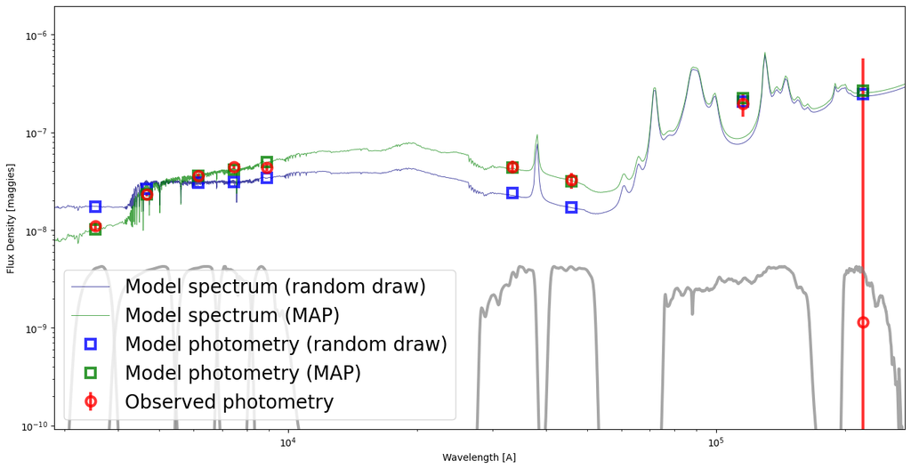

```python
# Make plot of data and model
plt.figure(figsize=(16,8))

plt.loglog(wspec, mspec, label='Model spectrum (random draw)',
       lw=0.7, color='navy', alpha=0.7)
plt.loglog(wspec, mspec_map, label='Model spectrum (MAP)',
       lw=0.7, color='green', alpha=0.7)
plt.errorbar(wphot, mphot, label='Model photometry (random draw)',
         marker='s', markersize=10, alpha=0.8, ls='', lw=3,
         markerfacecolor='none', markeredgecolor='blue',
         markeredgewidth=3)
plt.errorbar(wphot, mphot_map, label='Model photometry (MAP)',
         marker='s', markersize=10, alpha=0.8, ls='', lw=3,
         markerfacecolor='none', markeredgecolor='green',
         markeredgewidth=3)
plt.errorbar(wphot, obs['maggies'], yerr=obs['maggies_unc'],
         label='Observed photometry', ecolor='red',
         marker='o', markersize=10, ls='', lw=3, alpha=0.8,
         markerfacecolor='none', markeredgecolor='red',
         markeredgewidth=3)

# plot transmission curves
for f in obs['filters']:
    w, t = f.wavelength.copy(), f.transmission.copy()
    t = t / t.max()
    t = 10**(0.2*(np.log10(ymax/ymin)))*t * ymin
    plt.loglog(w, t, lw=3, color='gray', alpha=0.7)

plt.xlabel('Wavelength [A]')
plt.ylabel('Flux Density [maggies]')
plt.xlim([xmin, xmax])
plt.ylim([ymin/10,ymax])
plt.legend(loc='best', fontsize=20)
```

> Note: if you want to make these plots several times for different galaxies / fits, it may be useful to save this code as a separate Python file, e.g. `plotting.py`. You can then import these functions in this notebook or elsewhere without re-defining them.

#### Step 5

The code below loads in the table containing the photometry of all galaxies as a [Pandas DataFrame](https://pandas.pydata.org/). Select a sample of galaxies to run Prospector on.

```python
from astropy.table import Table
from astropy.io import fits

with fits.open('../data/sw_input.fits') as f:
    df = Table(f[1].data).to_pandas()
    f.close()

df.head()
```

|  | id | ra | dec | redshift | PLATE | MJD | FIBERID | designation | flux0_u | flux0_u_e | ... | flux_w2_e | flux_w3 | flux_w3_e | flux_w4 | flux_w4_e | extin_u | extin_g | extin_r | extin_i | extin_z |
| --- | --- | --- | --- | --- | --- | --- | --- | --- | --- | --- | --- | --- | --- | --- | --- | --- | --- | --- | --- | --- | --- |
| 0 | 3 | 337.450310 | 1.266134 | 0.088372 | 376 | 52143 | 404 | J222948.07+011558.1 | 0.000031 | 0.000003 | ... | 0.000049 | 4.172000e-07 | 0.000209 | 0.000002 | 0.001187 | 0.341327 | 0.265960 | 0.183990 | 0.136724 | 0.101698 |
| 1 | 5 | 338.115522 | 1.270146 | 0.163800 | 376 | 52143 | 567 | J223227.69+011612.6 | 0.000011 | 0.000004 | ... | 0.000111 | 9.851000e-07 | 0.000493 | 0.000004 | 0.001883 | 0.368063 | 0.286793 | 0.198402 | 0.147434 | 0.109664 |
| 2 | 8 | 341.101481 | 1.266255 | 0.143369 | 378 | 52146 | 404 | J224424.38+011558.3 | 0.000017 | 0.000003 | ... | 0.000039 | 1.013700e-06 | 0.000507 | 0.000008 | 0.003856 | 0.337630 | 0.263079 | 0.181997 | 0.135243 | 0.100596 |
| 3 | 12 | 341.870909 | 1.267913 | 0.275242 | 378 | 52146 | 567 | J224729.01+011604.3 | 0.000007 | 0.000003 | ... | 0.000106 | 9.999000e+00 | 9.999000 | 0.000009 | 0.004526 | 0.358145 | 0.279064 | 0.193055 | 0.143461 | 0.106709 |
| 4 | 14 | 342.686706 | 1.270160 | 0.089104 | 676 | 52178 | 373 |  | 0.000031 | 0.000003 | ... | 9.999000 | 9.999000e+00 | 9.999000 | 9.999000 | 9.999000 | 0.362289 | 0.282293 | 0.195289 | 0.145121 | 0.107943 |

5 rows × 49 columns

**Optional:** how did you choose your set of galaxies? It's okay if they are all random, but if you want, you can try to choose a sample you find interesting.

**Answer**: Sample of galaxies chosen below is randomly selected.

```python
# Set a seed so that we obtain the same random sample each time
np.random.seed(20726114)

# Select a random sample of galaxies from the input dataframe
sample = df.sample(5)

# Add in a first column that stores the index of the table itself
sample.insert(0, 'table_id', sample.index.to_list())

# Convert the sample to a table
t = Table.from_pandas(sample)

# Save the sample as a .fits file for later use
fname = '../data/sample.fits'
t.write(fname, format = 'fits', overwrite = True)
```

```python
# Read in the sample to check
with fits.open('../data/sample.fits') as f:
    sp = Table(f[1].data).to_pandas()
    f.close()

display(sp)
```

Don't forget to save your sample or at least note down the id's you used!

#### Step 6

Run Prospector on your chosen sample. Feel free to use the default code we provided, or try your own fitting / modelling parameters.

> Hint: you can use Jupyter to run something from the command line using `!`. This allows you to pass variables from your Jupyter environment as arguments in curly braces `{...}`. For example, you could run:

```
! python assignment_params.py --objid={your_index} --optimize --emcee
```

> If you are using Python without Jupyter, you can't use `!`, but you can use [subprocess.run()](https://docs.python.org/3/library/subprocess.html#subprocess.run) function.

```python
# Get the ids of each target in our sample
TableIds = sp['table_id'].values.T
GalIds = sp['id'].values.T

# Run Prospector on the chosen sample
for i in range(0, len(TableIds)):
    outname = 'gal{0}_id={1}_emcee'.format(TableIds[i], GalIds[i])
    ! cd ../ && python assignment_params.py --objid={TableIds[i]} --optimize --emcee --outfile={outname}
```

#### Step 7

The photometry of the galaxy changes based on how far away it is: galaxies further away are fainter, and their SED shifts more towards red wavelengths. This is one of the challenges of SED fitting: it's hard to break the degeneracy between galaxies that are red because they are intrinsically red (older stars), and galaxies that are red because they are far away.

By default, we give Prospector a *known* spectroscopic redshift for each galaxy. This means that it is not fitting one of the important degenarate parameters.

However, obtaining a spectroscopic redshift is difficult, as it requires measuring a galaxy spectrum - simple photometry is way easier. The galaxies we used in this project all have spectroscopy, but there are millions of galaxies that do not. For those objects, we need to fit the SED *and* redshift simultaneously.

Let's imagine that we don't know the redshift of our objects. For your sample, re-run the Prospector fits by setting redshift as one of the free parameters. You can change the redshift from fixed to free by using `--var-redshift` argument when calling `assignment_params.py`.

```python
# Get the ids of each target in our sample
TableIds = sp['table_id'].values.T
GalIds = sp['id'].values.T

# Run Prospector on the chosen sample
for i in range(0, len(TableIds)):
    outname = 'gal{0}_id={1}_emcee_varz'.format(TableIds[i], GalIds[i])
    ! cd ../ && python assignment_params.py --objid={TableIds[i]} --optimize --emcee --outfile={outname} --var_redshift
```

# Section 1

#### Step 1: Goodness-of-Fit

Choose one of your galaxies, load in the data, and plot the original data and the best fit with error bars.

Compute the goodness-of-fit ($\chi^2$) of your fit.

> Note: Prospector assumes the magnitudes are independent so you can to, but we'll come back to this later

```python
import matplotlib.colors as mcolors
import matplotlib.pyplot as plt
from astropy.table import Table
from astropy.io import fits
from corner import corner

# Read in the table with the sample galaxies
with fits.open('../data/sample.fits') as f:
    sp = Table(f[1].data).to_pandas()
    f.close()
```

```python
# Select the index of the galaxy we want to choose
# from the sample table
idx = 1

# Get the ids required to load in the best fit data
table_id = sp['table_id'].values.T[idx]
id = sp['id'].values.T[idx]

# Read in the model results
file_name = '../output/gal{0}_id={1}_emcee.h5'.format(table_id, id)
res, obs, model = reader.results_from(file_name)
sps = reader.get_sps(res)
```

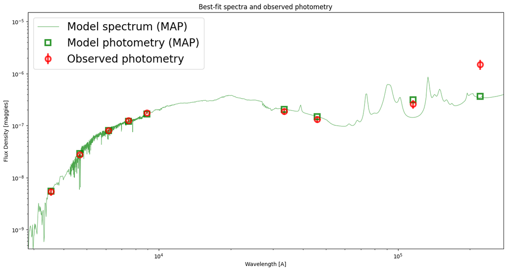

```python
# Index of the best chain / parameter vector
imax = np.argmax(res['lnprobability'])

# Selecting the best parameter vector
i, j = np.unravel_index(imax, res['lnprobability'].shape)
theta_max = res['chain'][i, j, :].copy()

# Apply cosmological redshifting
a = 1.0 + model.params.get('zred', 0.0)

# Find photometric effective wavelengths
wphot = obs["phot_wave"]

# spectroscopic wavelengths
# *restframe* spectral wavelengths, since obs["wavelength"] is None
wspec = sps.wavelengths
wspec *= a # redshift them

# Find bounds for plotting
xmin, xmax = np.min(wphot)*0.8, np.max(wphot)/0.8
ymin, ymax = obs["maggies"].min()*0.8, obs["maggies"].max()*10

# Get the model photometry and spectra
mspec_map, mphot_map, _ = model.mean_model(theta_max, obs, sps=sps)

# Make plot of data and model
plt.figure(figsize=(16,8))
plt.title('Best-fit spectra and observed photometry')
plt.loglog(wspec, mspec_map, label='Model spectrum (MAP)',
       lw=0.7, color='green', alpha=0.7)
plt.errorbar(wphot, mphot_map, label='Model photometry (MAP)',
         marker='s', markersize=10, alpha=0.8, ls='', lw=3,
         markerfacecolor='none', markeredgecolor='green',
         markeredgewidth=3)
plt.errorbar(wphot, obs['maggies'], yerr=obs['maggies_unc'],
         label='Observed photometry', ecolor='red',
         marker='o', markersize=10, ls='', lw=3, alpha=0.8,
         markerfacecolor='none', markeredgecolor='red',
         markeredgewidth=3)

plt.xlabel('Wavelength [A]')
plt.ylabel('Flux Density [maggies]')
plt.xlim([xmin, xmax])
plt.ylim([ymin/10,ymax])
plt.legend(loc='best', fontsize=20)
plt.show()
```

Assuming independent magnitudes, we can compute the $\chi^2$ statistic using the following formula: $$ \chi^2 = \sum_i^N \left(\frac{\left[y_i-m_i\right]^2}{\sigma_i^2}\right) $$ where $y_i$ are our observed photometry, $m_i$ are our model photometry, and $\sigma_i$ are the errors on our observed photometery. We can then use the $\chi^2$ statistic to evaluate the goodness of fit by comparing our $\chi^2$ to that of a $\chi^2$ distribution with $N - m$ degrees of freedom. Here $N$ is the number of data points and $m$ is the number of free parameters. Our fitting used the "parametric_sfh" model from the template library. According to the "assignment_params.py" file, this model has 5 free parameters: "mass", "logzsol", "dust2", "tage", "tau" since we are not varying redshift in this example. Thus, we have $m = 5$.

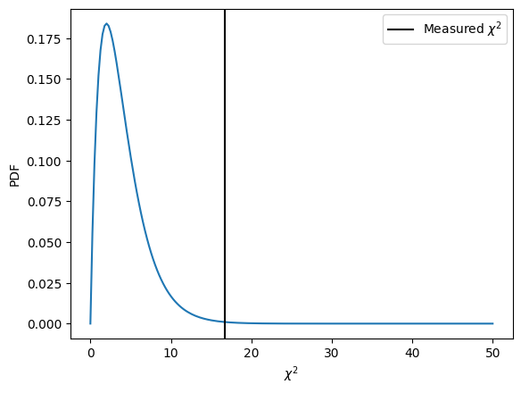

```python
# Compute the chi^2 statistic for our fit
X2 = np.sum( (obs['maggies'] - mphot_map)**2 / obs['maggies_unc']**2 )

# Compare this to a chi^2 distribution
from scipy.stats import chi2

rv = chi2(df = len(obs['maggies']) - 5)

c = np.linspace(0,50,200)
plt.plot(c, rv.pdf(c))
plt.axvline(X2, color = 'black', label = 'Measured $\\chi^2$')
plt.xlabel(r"$\chi^2$")
plt.ylabel("PDF")
plt.legend()

# Compute the p-value
p_value = 1.0 - rv.cdf(X2)

# Compute the reduced chi^2
reduced_X2 = X2 / (len(obs['maggies']) - 5)
```

```python
print('The p-value is:', p_value)
print('The reduced chi^2 is:', reduced_X2)
```

```
The p-value is: 0.0021913074562931456
The reduced chi^2 is: 4.179833284037254
```

Is your goodness-of-fit reasonable? Why / why not?

Our null hypothesis is that our model is a good fit to the data. Typically, the largest $p$-value that should be considered significant is $0.05$. A $p$-value less than this threshold rules out the null hypothesis. For this particular galaxy in our sample, we have a p-value of $\sim 0.002$ which is less than $0.05$. Therefore, we reject our null hypothesis, indicating that the model is not a good fit to the data. This is further confirmed by the reduced $\chi^2$ value of $\sim 4.18$. A reduced $\chi^2$ much larger than $1$ indicates that either the errors are underestimated or the model is not a good description of the data.

#### Step 2: Fit results

What are the best fit, mean, and $1\sigma$, $2\sigma$, $3\sigma$ confidence intervals for each of the constrained parameters?

```python
# Define a function to extract the fit results for each constrained parameter
def extract_fit(chains):

    # Flatten the chains
    states = np.array(chains.flatten())

    # Get the mean value
    s_mean = np.mean(states)

    # Get the percentiles necessary for the confidence intervals
    s_percentile = np.percentile(states, [0.15, 2.5, 16, 50, 84, 97.5, 99.85])

    # Calculate the confidence intervals
    s_median = s_percentile[3]
    sigma_1 = np.array([s_percentile[2], s_percentile[4]])
    sigma_2 = np.array([s_percentile[1], s_percentile[5]])
    sigma_3 = np.array([s_percentile[0], s_percentile[6]])

    # Return the mean and percentiles
    return (s_mean, s_median, sigma_1, sigma_2, sigma_3)

# End of function definition

# Determine the number of fit parameters we have
nParams = res['chain'].shape[2]

# Extract the fit parameters that are free
param_names = []
for param in res['model_params']:
    if (param['isfree']):
        param_names.append(param['name'])
    # End of if
# End of for loop

# Iterate over each parameter
for i in range(0, nParams):

    # Get the best fit value for the parameter
    s_best = res['bestfit']['parameter'][i]

    # Get the mean and confidence intervals for the parameter
    # Note: These chains have the burn-in phase removed
    (s_mean, _, sigma_1, sigma_2, sigma_3) = extract_fit(res['chain'][:, :, i])

    # Print the results for the parameter
    print('Fit results for {0}'.format(param_names[i]))
    print('Best fit:', s_best)
    print('Mean:', s_mean)
    print('1-sigma interval:', sigma_1)
    print('2-sigma interval:', sigma_2)
    print('3-sigma interval:', sigma_3)
    print('\n')

# End of for loop
```

```
Fit results for mass
Best fit: 176816709536.37833
Mean: 62930455959.651215
1-sigma interval: [5.16220535e+09 1.29999514e+11]
2-sigma interval: [2.01762146e+09 1.90603196e+11]
3-sigma interval: [1.75620433e+09 3.05899366e+11]


Fit results for logzsol
Best fit: -0.05145810780303589
Mean: -0.33350511223785895
1-sigma interval: [-0.4995874  -0.16545248]
2-sigma interval: [-0.69292299  0.00613467]
3-sigma interval: [-0.89455511  0.16564066]


Fit results for dust2
Best fit: 0.5918053559075889
Mean: 0.4886710035362788
1-sigma interval: [0.32695436 0.64166153]
2-sigma interval: [0.16781812 0.75559028]
3-sigma interval: [0.05871858 0.9450034 ]


Fit results for tage
Best fit: 3.0847447623479463
Mean: 7.833522205336907
1-sigma interval: [ 1.22115394 12.70850299]
2-sigma interval: [ 0.36674434 13.64857107]
3-sigma interval: [ 0.27175027 13.79466627]


Fit results for tau
Best fit: 0.25562871220224626
Mean: 12.639460408482085
1-sigma interval: [ 3.06080214 23.53912276]
2-sigma interval: [ 0.28803206 28.62910369]
3-sigma interval: [ 0.11655694 29.93702208]
```

Are your results consistent with the fit from Chang et al.? (You can look up their values in the [output catalog](https://irfu.cea.fr/Pisp/yu-yen.chang/sw.html)).

How similar do we expect them to be?

```python
# Load in the output catalogue
with fits.open('../data/sw_output.fits') as f:
    out_cat = Table(f[1].data).to_pandas()
    f.close()

# Find where to look in the output catalogue
out_idx = np.where(out_cat['id'].values.T == id)[0][0]
```

```
Did Chang+2015 identify this galaxy with a good fit? Yes
```

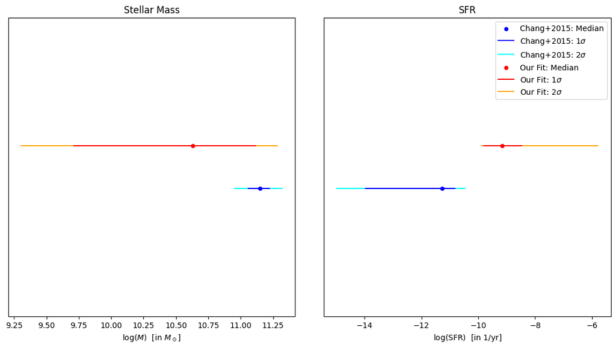

```python
# Calculate the SFR distribution
# Note: The last factor is convert values into years
chains_SFR = res['chain'][:, :, 3] * np.exp(-res['chain'][:, :, 3]/res['chain'][:, :, 4]) * 1e9

# Plot a comparison between our values and Chang et al.
fig = plt.figure(figsize = (14, 7))
gs = fig.add_gridspec(1, 2, wspace = 0.1, hspace = 0.0)

# Loop over each axis
for i in range(0, 2):

    # Determine which parameter we are plotting
    if (i == 0):
        title = 'Stellar Mass'
        t_param = 'lmass'
        chains = res['chain'][:, :, 0]
        xlabel = '$\log(M)$  [in $M_\odot$]'
    elif (i == 1):
        title = 'SFR'
        t_param = 'lssfr'
        chains = chains_SFR**-1
        xlabel = '$\log(\\rm{SFR})$  [in $1/\\rm{yr}$]'
    # End of if

    # Add an axis to the plot
    ax = fig.add_subplot(gs[0, i])

    # Add the title to the plot
    ax.title.set_text(title)

    # Read in the data from the output catalogue
    chang_med = out_cat.at[out_idx, '{0}50_all'.format(t_param)]
    chang_sigma1 = np.array([out_cat.at[out_idx, '{0}16_all'.format(t_param)],
                             out_cat.at[out_idx, '{0}84_all'.format(t_param)]])
    chang_sigma2 = np.array([out_cat.at[out_idx, '{0}2_5_all'.format(t_param)],
                             out_cat.at[out_idx, '{0}97_5_all'.format(t_param)]])

    # Get the median and confidence intervals for our fit
    (_, s_med, s_sigma1, s_sigma2, _) = extract_fit(chains)

    # Transform these values to be equivalent to Chang+2015
    s_med = np.log10(s_med)
    s_sigma1 = np.log10(s_sigma1)
    s_sigma2 = np.log10(s_sigma2)

    # Add the data to the plot
    ax.scatter(chang_med, 1, color = 'blue', s = 20, marker = 'o', zorder = 3, label = 'Chang+2015: Median')
    ax.plot(chang_sigma1, [1, 1], color = 'blue', linestyle = 'solid', marker = None, zorder = 2, label = 'Chang+2015: 1$\sigma$')
    ax.plot(chang_sigma2, [1, 1], color = 'cyan', linestyle = 'solid', marker = None, zorder = 1, label = 'Chang+2015: 2$\sigma$')
    ax.scatter(s_med, 2, color = 'red', s = 20, marker = 'o', zorder = 3, label = 'Our Fit: Median')
    ax.plot(s_sigma1, [2, 2], color = 'red', linestyle = 'solid', marker = None, zorder = 2, label = 'Our Fit: 1$\sigma$')
    ax.plot(s_sigma2, [2, 2], color = 'orange', linestyle = 'solid', marker = None, zorder = 1, label = 'Our Fit: 2$\sigma$')

    ax.set_xlabel(xlabel)
    ax.set_ylim([-2, 5])
    ax.set_yticks([])

    # Add a legend to the plot
    if (i == 1):
        ax.legend()

# # End of for loop

# Get the good fit flag for this galaxy
good_fit = out_cat.at[out_idx, 'flag']
if good_fit:
    ans = 'Yes'
else:
    ans = 'No'
# End of if

print('Did Chang+2015 identify this galaxy with a good fit?', ans)
```

In the plot above, we compare the stellar mass of our galaxy and it's SFR to that of the fit in Chang+2015. Our fit results are shown in red, while the results from Chang+2015 are shown in blue. It was not clear which other output parameters in Chang+2015 were directly comparable to our model's free parameters.

For both stellar mass and SFR, the median of our fits lie outside the 2$\sigma$ confidence limits of Chang+2015. For SFR, the 2$\sigma$ limits of our fit do not overlap with that from Chang+2015. For stellar mass, the median value of Chang+2015 lies just outside our fit's 1$\sigma$ limits.

In general, our results are partially consistent with the values from Chang+2015. We wouldn't expect them to be very similar since in step 1 above, we found that our model was poorly fit to the data for this galaxy. In contrast, Chang+2015 found that their best-fit model was a good fit to the data.

#### Step 3: Comparing samples

Check the probability distribution of a single parameter (e.g., stellar mass) for a single galaxy and compare to the result from Chang et al. How different do you expect them to be? what does this tell you about the models you and Chang et al are fitting? You can try for a few different galaxies if you like to see if your conclusions are the same

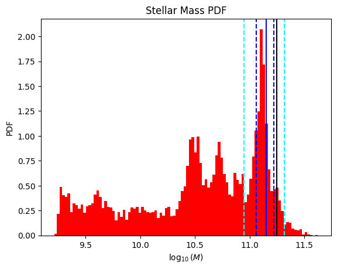

```python
# Get the distribution for stellar mass
mass_array = res['chain'][:, :, 0].flatten()

# Get the best-fit value for our sample
m_best = res['bestfit']['parameter'][0]

# Get the results from Chang+2015
chang_mass_med = out_cat.at[out_idx, 'lmass50_all']
chang_mass_sigma1 = np.array([out_cat.at[out_idx, 'lmass16_all'],
                              out_cat.at[out_idx, 'lmass84_all']])
chang_mass_sigma2 = np.array([out_cat.at[out_idx, 'lmass2_5_all'],
                              out_cat.at[out_idx, 'lmass97_5_all']])


# Plot the probability distribution for stellar mass
plt.title('Stellar Mass PDF')
plt.hist(np.log10(mass_array), bins = 100, density = True, color = 'red', zorder = 1)
plt.axvline(np.log10(m_best), color = 'black', linestyle = 'solid', zorder = 2)
plt.axvline(chang_mass_med, color = 'blue', linestyle = 'solid', zorder = 2)
plt.axvline(chang_mass_sigma1[0], color = 'blue', linestyle = 'dashed', zorder = 2)
plt.axvline(chang_mass_sigma1[1], color = 'blue', linestyle = 'dashed', zorder = 2)
plt.axvline(chang_mass_sigma2[0], color = 'cyan', linestyle = 'dashed', zorder = 2)
plt.axvline(chang_mass_sigma2[1], color = 'cyan', linestyle = 'dashed', zorder = 2)
plt.xlabel('$\log_{10}(M)$')
plt.ylabel('PDF')
plt.show()
```

The plot above shows a comparison between our probability distribution for the stellar mass and the result from Chang+2015. The black line shows our best fit value, while the blue solid line shows the median stellar mass from Chang+2015. Finally, the blue and cyan dotted lines show the $1\sigma$ and $2\sigma$ confidence limits in the stellar mass from Chang+2015, respectively.

We see that for this particular galaxy, the stellar mass probability distribution is much broader compared to Chang+2015. The $2\sigma$ confidence limits for Chang+2015 only overlap with a small section of our distribution. When looking at other galaxies, in general our stellar mass distribution is wider than the Chang+2015 confidence limits, and the median stellar mass in Chang+2015 can be either larger or smaller than our best-fit value.

This result shows that the probability distribution for stellar mass we find is considerably different than that from Chang+2015. In principle, we would expect our results to be slightly different at least since we are using different fitting codes (MAGPHYS for Chang+2015), however, it is surprising our distribution is so wide compared to Chang+2015, even after accounting for burn-in from emcee. In this particular case, our best-fit value and the peak of the probability distribution fall within the 2$\sigma$ limits of Chang+2015. However, in general this is not true and our best fit value can fall outside the 2$\sigma$ limits. This likely implies the model we are fitting and its free parameters are different from Chang+2015. The weight/importance of each parameter is likely different as well.

#### Step 4: Redshift

How did allowing the redshift as a free parameter change the results? Did you get the same mass? Is the redshift correct?

```python
# Read in the same galaxy but with redshift as a free parameter
file_name2 = '../output/gal{0}_id={1}_emcee_varz.h5'.format(table_id, id)
res_red, obs_red, model_red = reader.results_from(file_name2)
sps_red = reader.get_sps(res_red)
```

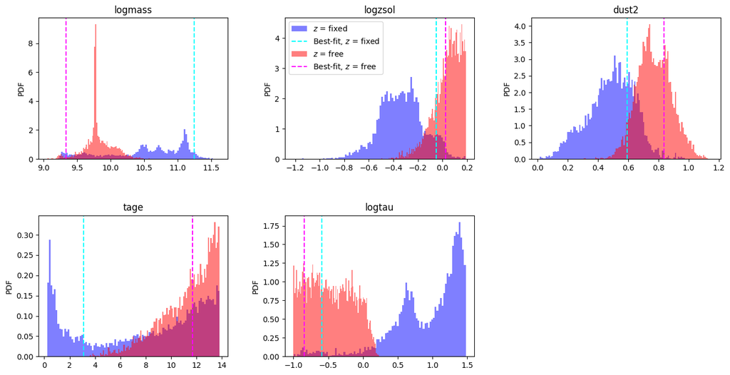

```python
# Plot a comparison of the distributions varying and not varying redshift
fig = plt.figure(figsize = (16, 8))
gs = fig.add_gridspec(2, 3, wspace = 0.3, hspace = 0.4)

# Select indices to extract the parameters
# Note: b = 1 since redshift is the first parameter
a = 0
b = 1

# Loop over each axis
for i in range(0, 2):
    for j in range(0, 3):

        # Determine which parameter we are plotting
        if (i == 1) & (j == 2):
            continue
        # End of if

        # Add an axis to the plot
        ax = fig.add_subplot(gs[i, j])

        # Get the data for the plot
        title = param_names[a]
        best_fit = res['bestfit']['parameter'][a]
        chains = res['chain'][:, :, a].flatten()
        best_fit_red = res_red['bestfit']['parameter'][b]
        chains_red = res_red['chain'][:, :, b].flatten()

        # If we are looking at mass, log10 values
        if (i == 0) & (j == 0) | (i == 1) & (j == 1):
            title = 'log' + title
            best_fit = np.log10(best_fit)
            chains = np.log10(chains)
            best_fit_red = np.log10(best_fit_red)
            chains_red = np.log10(chains_red)
        # End of if

        # Add the title to the plot
        ax.title.set_text(title)

        # Add the data to the plot
        ax.hist(chains, bins = 100, density = True, color = 'blue', alpha = 0.5, zorder = 1, label = '$z$ = fixed')
        ax.axvline(best_fit, color = 'cyan', linestyle = 'dashed', zorder = 2, label = 'Best-fit, $z$ = fixed')
        ax.hist(chains_red, bins = 100, density = True, color = 'red', alpha = 0.5, zorder = 1, label = '$z$ = free')
        ax.axvline(best_fit_red, color = 'magenta', linestyle = 'dashed', zorder = 2, label = 'Best-fit, $z$ = free')

        # Add labels to the axes
        ax.set_ylabel('PDF')

        # Add a legend
        if (i == 0) & (j == 1):
            ax.legend()

        # Iterate to next values
        a += 1
        b += 1

    # End of for loop
# End of for loop
```

```python
# Calculate mass and 1-sigma limits

# Fixed Redshift
m_best = res['bestfit']['parameter'][0]
(_, m_med, m_sigma_1, _, _) = extract_fit(res['chain'][:, :, 0])

print('Results for {0} when redshift is fixed.'.format(param_names[0]))
print('Best fit:', np.log10(m_best))
print('Median:', np.log10(m_med))
print('1-sigma interval:', np.log10(m_sigma_1))
print('\n')

# Free Redshift
m_best = res_red['bestfit']['parameter'][1]
(_, m_med, m_sigma_1, _, _) = extract_fit(res_red['chain'][:, :, 1])

print('Results for {0} when redshift is free.'.format(param_names[0]))
print('Best fit:', np.log10(m_best))
print('Median:', np.log10(m_med))
print('1-sigma interval:',np.log10(m_sigma_1))
print('\n')

# Calculate redshift and 1-sigma limits
r_best = res_red['bestfit']['parameter'][0]
(_, r_med, r_sigma_1, _, _) = extract_fit(res_red['chain'][:, :, 0])

print('Results for redshift when redshift is free.')
print('Best fit:', r_best)
print('Median:', r_med)
print('1-sigma interval:', r_sigma_1)
print('\n')

# Get actual galaxy redshift from input catalogue
sp_idx = np.where(table_id == sp['table_id'].values.T)[0][0]
print('Redshift given in the input catalogue, z = {0} .'.format(sp.at[sp_idx, 'redshift']))
```

```
Results for mass when redshift is fixed.
Best fit: 11.24752330432264
Median: 10.62955620969632
1-sigma interval: [ 9.71283528 11.11394173]


Results for mass when redshift is free.
Best fit: 9.337584233759147
Median: 9.77791952626111
1-sigma interval: [ 9.66695546 10.03471139]


Results for redshift when redshift is free.
Best fit: 0.012362034412641608
Median: 0.022155487248643857
1-sigma interval: [0.01837656 0.02990828]


Redshift given in the input catalogue, z = 0.1844941825 .
```

The largest difference in the two cases is the estimated mass of the galaxy. For a fixed redshift, the best-fit mass is $\sim 10^{11.25} M_\odot$ compared to $\sim 10^{9.34} M_\odot$ when the redshift is a free parameter. The distributions for the mass are also very different and do not coincide. This is likely caused by the best-fit being far from the true redshift of the galaxy. We find that the best-fit redshift when this is left as a free parameter is $0.012$ with a $1\sigma$ confidence interval of $[0.018, 0.030]$ compared to $0.184$ from the input catalogue. The model converging to the incorrect redshift likely affected some of the other free parameters as well, leading to the differences we see.

# Section 2

#### Step 1: Covariance

First lets look at the covariance of constrained parameters for one of your fits. Plot a corner plot of the prospector outputs, showing the 68% and 95% 2D contours. Remember, you can refer to the Prospector Example notebook on how to make a corner plot.

Are there any degeneracies between parameters in the fit? What does this mean?  
How do the degeneracies change if we fix redshift or if we try to vary it?

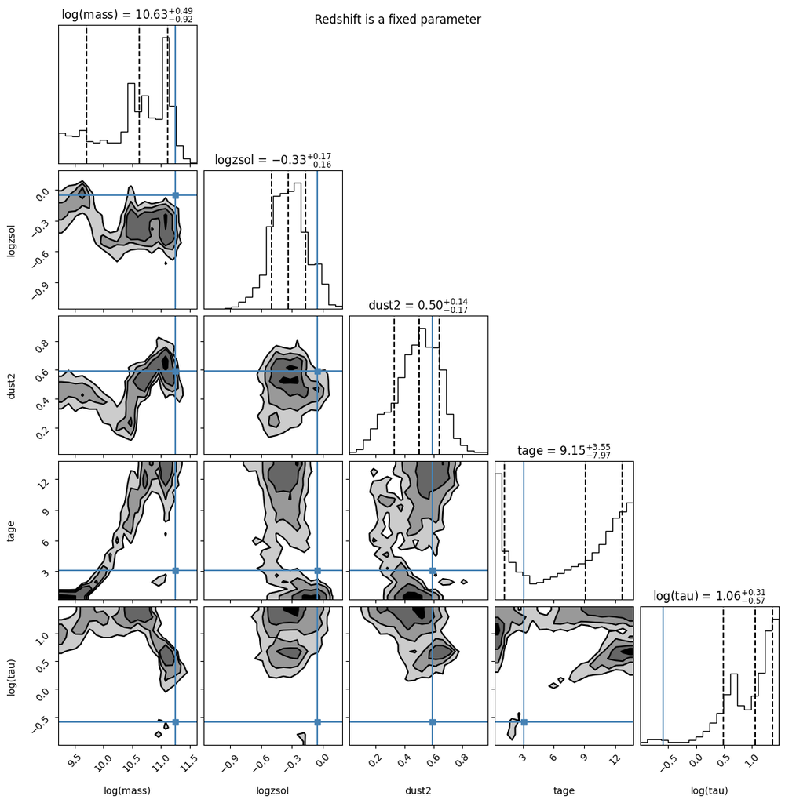

```python
import prospect.io.read_results as reader

## Plot a corner plot for the fixed redshift example ##

fig = reader.subcorner(res, truths = res['bestfit']['parameter'].copy(), thin = 5, show_titles = True)
fig.suptitle('Redshift is a fixed parameter')
plt.show()
```

Degenerate parameters are ones that have two separated peaks in the two parameter contour plots above. This means that in the bivariate distributions of the two parameters, there are two different sets of parameters for the model that are well fit to the data. In this case, the two sets of parameters would produce model spectra that are both best-fit to the observed photometry.

In the case where redshift is a fixed parameter, we do see some degeneracies. The primary degeneracy exists between age and the other four model parameters. For a given metallicity, dust optical depth, and SFR decay timescale ($\tau$), the galaxy can be either very old or very young. In the case of mass, the degeneracy is more split. A lower mass galaxy would be younger while a higher mass galaxy would be older.

Another degeneracy we see is between mass and metallicity. For a given metallicity, both high mass and low mass galaxies can be best-fit.

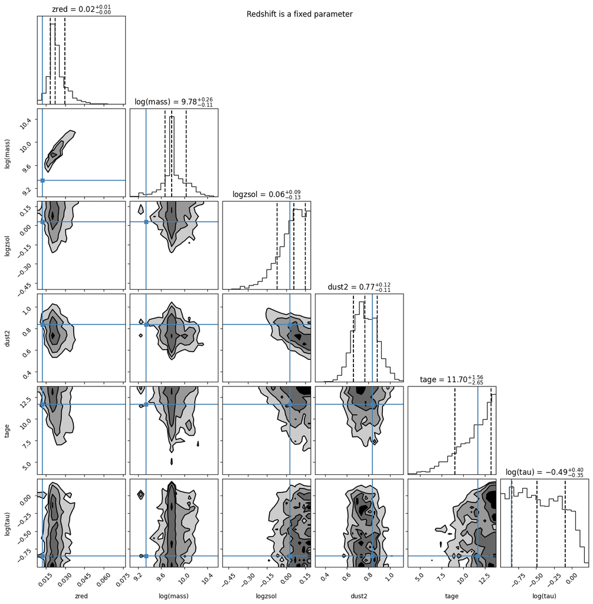

```python
## Plot a corner plot for the free redshift example ##

fig = reader.subcorner(res_red, truths = res_red['bestfit']['parameter'].copy(), thin = 5, show_titles = True)
fig.suptitle('Redshift is a fixed parameter')
plt.show()
```

In the case where we allow redshift to vary as a free parameter, many of the previous degeneracies we had disappear. The primary degeneracy now exists between the SFR decay timescale ($\tau$) and the other five parameters. These five parameters have the widths of their distributions pretty well constrained, but as we can see in the bivariate distributions, both more negative (smaller) and less negative (larger) values of $\log(\tau)$ in the model can be best-fit to the observed data.

#### Step 2: Covariance matrix

The covariance matrix describes the uncertainties of parameters, and their covariance with each other. Make the covariance matrix for one of your fits and plot it.

Looking at the contour plot, was this a reasonable thing to do? i.e. Is your covariance matrix a good descriptor of your posterior

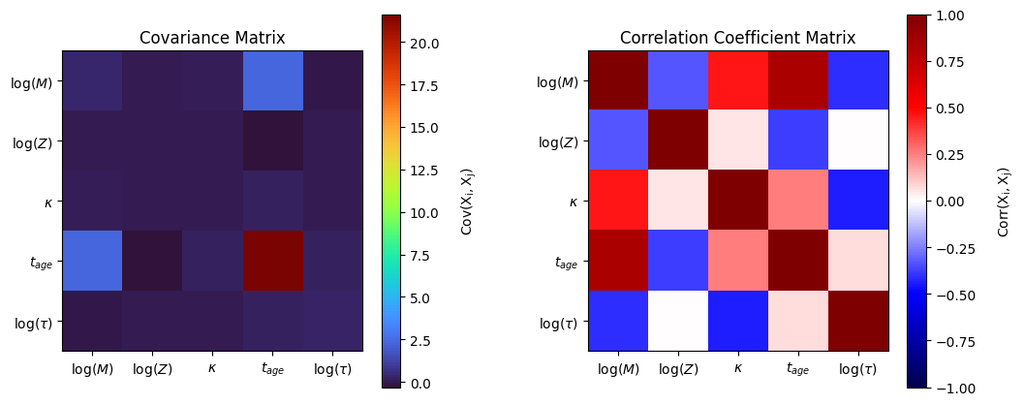

```python
# Get the MCMC chains and reshape them into a useable form
(nChains, nSteps, nParams) = res['chain'].shape
chains = res['chain'].copy().reshape(nChains * nSteps, nParams)
chains[:, 0] = np.log10(chains[:, 0])
chains[:, 4] = np.log10(chains[:, 4])

# Calculate the covariance matrix
cov = np.cov(chains.T)

# Calculate the correlation coefficients
corr = np.corrcoef(chains.T)

# Set the labels for our plot
lab = ['$\log(M)$', '$\log(Z)$', '$\kappa$', '$t_{age}$', '$\log(\\tau)$']

# Plot the covariance and correlation coefficent matrices
fig = plt.figure(figsize = (12, 5))
gs = fig.add_gridspec(1, 2, wspace = 0.4, hspace = 0.0)

ax1 = fig.add_subplot(gs[0, 0])
ax2 = fig.add_subplot(gs[0, 1])

ax1.title.set_text('Covariance Matrix')
ax2.title.set_text('Correlation Coefficient Matrix')
im1 = ax1.imshow(cov, interpolation = 'nearest', origin = 'upper', cmap = 'turbo')
im2 = ax2.imshow(corr, interpolation = 'nearest', origin = 'upper', vmin = -1.0, vmax = 1.0, cmap = 'seismic')

# Set the tick labels
ax1.set_xticks([0, 1, 2, 3, 4])
ax1.set_xticklabels(lab)
ax1.set_yticks([0, 1, 2, 3, 4])
ax1.set_yticklabels(lab)
ax2.set_xticks([0, 1, 2, 3, 4])
ax2.set_xticklabels(lab)
ax2.set_yticks([0, 1, 2, 3, 4])
ax2.set_yticklabels(lab)

# Add a colourbar
cbar1 = fig.colorbar(im1, orientation = 'vertical')
cbar1.ax.set_ylabel('$\\rm{Cov}(X_i, X_j)$', rotation = 90, labelpad = 15)
cbar2 = fig.colorbar(im2, orientation = 'vertical')
cbar2.ax.set_ylabel('$\\rm{Corr}(X_i, X_j)$', rotation = 90, labelpad = 15)

plt.show()
```

In the figure above, we plot the raw covariance matrix and the correlation coefficient matrix for our set of free parameters for one particular galaxy, assuming that redshift is fixed. The values along the diagonal of the covariance matrix are related to the errors on the parameters. Larger values for the covariance along the diagonal (i.e., the variance in a given parameter) should indicate wider errorbars. This is difficult to see directly from the raw covariance matrix since different parameters are on different scales, but we can see that $t_\rm{age}$ has the largest variance and largest errors in the contour plot.

However, in the case for this particular galaxy with fixed redshift, our covariance matrix is not a good descriptor of the posterior distribution. This is because many of our parameters (i.e., mass, age, and $\tau$) do not look like they are sampled from Gaussian distributions when looking at the contour plot in step 1. If the free parameters are not sampled from a Gaussian distribution, then the covariance matrix is not sufficient to describe the uncertainty on the parameters.

#### Step 3: Covariance of magnitude errors

So far, Prospector has assumed the uncertainties in the magnitudes/fluxes are independent of each other. In practice this might not be true. For this exercise, assume the correlation between the flux in each band is X%.

Plot the covariance matrix, with and without the correlated errors.

Suppose $Y$ and $Z$ are two random variables. Then, the correlation coefficient is related to their covariances by, $$ \rho(Y,Z) = \frac{\rm{Var}(Y,Z)}{\sqrt{\rm{Var}(Y)\rm{Var}(Z)}} $$ Given the correlation between our random variables is $x$, then we can solve for the covariance, $$ \rm{Var}(Y,Z) = x \, \sigma_y \sigma_z $$ where $\sigma_y = \sqrt{\rm{Var}(y)}$ and $\sigma_z = \sqrt{\rm{Var}(z)}$. These can be computed directly from the uncertainties in $Y$ and $Z$.

```python
# Set the correlation between each band
x_corr = 0.30

# Get the number of observed bands we have
nBands = len(obs['maggies'])

# Set vectors to store the covariance matrix in each case
cov_uncorr = np.zeros((nBands, nBands))
cov_corr = np.zeros((nBands, nBands))
corr_uncorr = np.zeros((nBands, nBands))
corr_corr = np.zeros((nBands, nBands))

# Loop over each element in the covariance matrix
for i in range(0, nBands):
    for j in range(0, nBands):

        # Calculate the covariance
        if (i != j):
            cov_uncorr[i, j] = 0.0 * obs['maggies_unc'][i] * obs['maggies_unc'][j]
            cov_corr[i, j] = x_corr * obs['maggies_unc'][i] * obs['maggies_unc'][j]
        else:
            cov_uncorr[i, j] = obs['maggies_unc'][i] * obs['maggies_unc'][j]
            cov_corr[i, j] = obs['maggies_unc'][i] * obs['maggies_unc'][j]
        # End of if

        # Calculate the correlation coefficients
        if (i != j):
            corr_uncorr[i, j] = 0.0
            corr_corr[i, j] = x_corr
        else:
            corr_uncorr[i, j] = 1.0
            corr_corr[i, j] = 1.0
        # End of if

    # End of for loop
# End of for loop
```

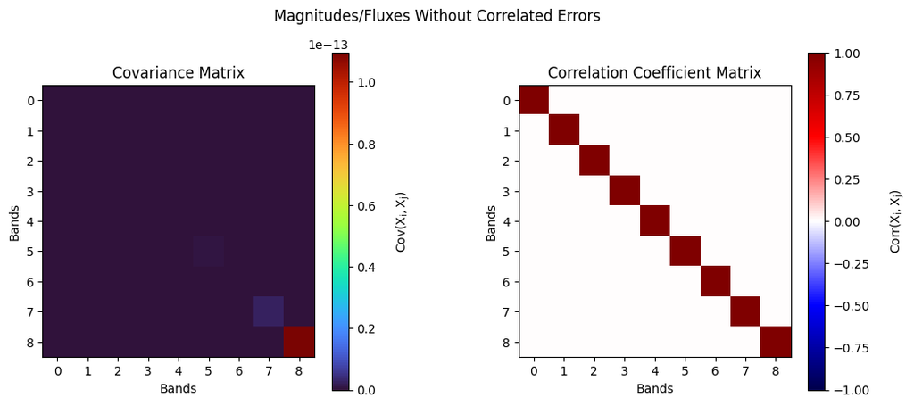

```python
# Plot the covariance and correlation coefficent matrices
fig = plt.figure(figsize = (12, 5))
gs = fig.add_gridspec(1, 2, wspace = 0.4, hspace = 0.0)

fig.suptitle('Magnitudes/Fluxes Without Correlated Errors')

ax1 = fig.add_subplot(gs[0, 0])
ax2 = fig.add_subplot(gs[0, 1])

ax1.title.set_text('Covariance Matrix')
ax2.title.set_text('Correlation Coefficient Matrix')
im1 = ax1.imshow(cov_uncorr, interpolation = 'nearest', origin = 'upper', cmap = 'turbo')
im2 = ax2.imshow(corr_uncorr, interpolation = 'nearest', origin = 'upper', vmin = -1.0, vmax = 1.0, cmap = 'seismic')

# Set the tick labels
ax1.set_xticks(list(range(0, nBands)))
ax1.set_yticks(list(range(0, nBands)))
ax2.set_xticks(list(range(0, nBands)))
ax2.set_yticks(list(range(0, nBands)))

# Set the axis labels
ax1.set_xlabel('Bands')
ax1.set_ylabel('Bands')
ax2.set_xlabel('Bands')
ax2.set_ylabel('Bands')

# Add a colourbar
cbar1 = fig.colorbar(im1, orientation = 'vertical')
cbar1.ax.set_ylabel('$\\rm{Cov}(X_i, X_j)$', rotation = 90, labelpad = 15)
cbar2 = fig.colorbar(im2, orientation = 'vertical')
cbar2.ax.set_ylabel('$\\rm{Corr}(X_i, X_j)$', rotation = 90, labelpad = 15)

plt.show()
```

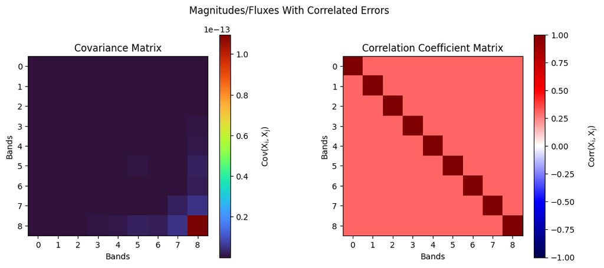

```python
# Plot the covariance and correlation coefficent matrices
fig = plt.figure(figsize = (12, 5))
gs = fig.add_gridspec(1, 2, wspace = 0.4, hspace = 0.0)

fig.suptitle('Magnitudes/Fluxes With Correlated Errors')

ax1 = fig.add_subplot(gs[0, 0])
ax2 = fig.add_subplot(gs[0, 1])

ax1.title.set_text('Covariance Matrix')
ax2.title.set_text('Correlation Coefficient Matrix')
im1 = ax1.imshow(cov_corr, interpolation = 'nearest', origin = 'upper', cmap = 'turbo')
im2 = ax2.imshow(corr_corr, interpolation = 'nearest', origin = 'upper', vmin = -1.0, vmax = 1.0, cmap = 'seismic')

# Set the tick labels
ax1.set_xticks(list(range(0, nBands)))
ax1.set_yticks(list(range(0, nBands)))
ax2.set_xticks(list(range(0, nBands)))
ax2.set_yticks(list(range(0, nBands)))

# Set the axis labels
ax1.set_xlabel('Bands')
ax1.set_ylabel('Bands')
ax2.set_xlabel('Bands')
ax2.set_ylabel('Bands')

# Add a colourbar
cbar1 = fig.colorbar(im1, orientation = 'vertical')
cbar1.ax.set_ylabel('$\\rm{Cov}(X_i, X_j)$', rotation = 90, labelpad = 15)
cbar2 = fig.colorbar(im2, orientation = 'vertical')
cbar2.ax.set_ylabel('$\\rm{Corr}(X_i, X_j)$', rotation = 90, labelpad = 15)

plt.show()
```

Re-compute the goodness of fit with the correlated errors.  
Did the goodness-of-fit get worse or better, why?

```python
# Calculate the inverse covariance matrices
inv_cov_uncorr = np.linalg.inv(cov_uncorr)
inv_cov_corr = np.linalg.inv(cov_corr)

# Calculate the model - data vector
diff_vec = mphot_map - obs['maggies']

# Compute the goodness of fit statistic in each case
chi2_uncorr = diff_vec.T @ (inv_cov_uncorr @ diff_vec)
chi2_corr = diff_vec.T @ (inv_cov_corr @ diff_vec)

# Print the result
print('Goodness of fit with uncorrelated errors:', chi2_uncorr)
print('Goodness of fit with {0}% correlated errors:'.format(x_corr * 100), chi2_corr)
```

```
Goodness of fit with uncorrelated errors: 16.719333136149015
Goodness of fit with 30.0% correlated errors: 23.749709668438637
```

The goodness of fit with the correlated errors is a larger value than that with the uncorrelated errors. The reason the goodness of fit got worse is because all of our flux bands have positive correlations. In the uncorrelated case, all the off-diagonal terms in the covariance matrix are zero. However, in the correlated case, since the flux bands have positive correlations, the off-diagonal terms in the covariance matrix are all positive. This carries forward into calculating the goodness of fit, where the positive off-diagonal terms are all added together resulting in a larger $\chi^2$ compared to the uncorrelated case.

If the flux bands were instead negatively correlated, then the off-diagonal terms would be negative. This would result in a lower $\chi^2$ value compared to the uncorrelated case.

# Section 3

#### Estimating the uncertainties

For this section, we will use the output catalogs, since running prospector on all 800000 galaxies would be a waste of computing for this class.

Plot a histogram of a given measured quantity (stellar mass, redshift, etc). Choose the range and bin size appropriately so that we can see the full distribution.

```python
# Read in the input catalogue
with fits.open('../data/sw_input.fits') as f:
    in_cat = Table(f[1].data).to_pandas()
    f.close()
```

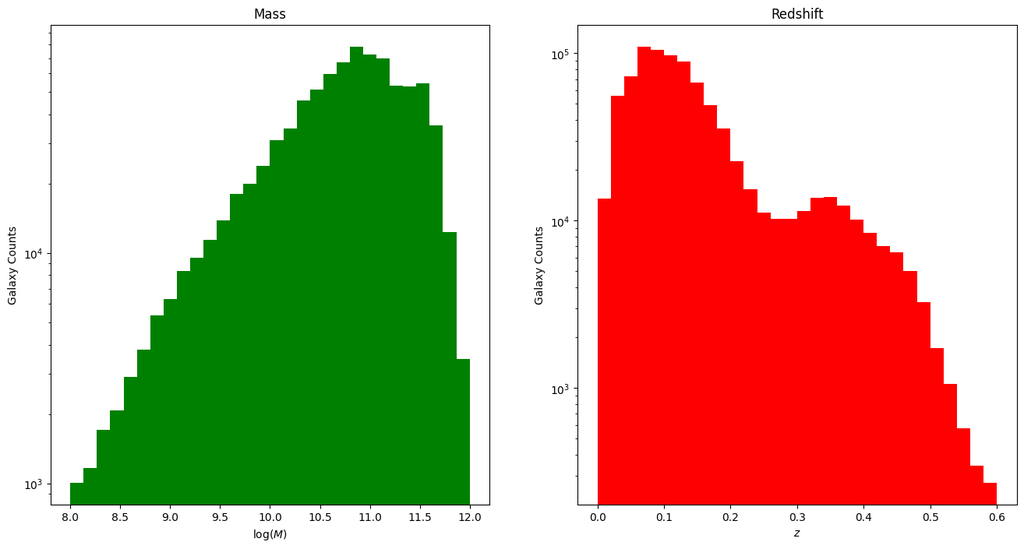

```python
# Select the free parameter we want to plot
model_param = 'lmass'

# Set the ranges for each parameter
pL, pR = 8.0, 12.0
zL, zR = 0.0, 0.6

# Extract the redshift information from the input catalogue
z_vec = in_cat['redshift'].values.T

# Extract the parameter information from the output catalogue
# Note: We are assuming the true parameter value is the 50% percentile
p_vec = out_cat['{0}50_all'.format(model_param)].values.T

# Remove values outside the desired ranges
z_vec = z_vec[(zL <= z_vec) & (z_vec <= zR)]
p_vec = p_vec[(pL <= p_vec) & (p_vec <= pR)]

## For stellar mass ##

# Set the number of bins we want
nBins = 30

# Calculate the bin spacing
bin_size = (pR - pL) / nBins

# Calculate the bin edges
bin_edges = np.arange(pL, pR + bin_size, bin_size)

## ##

# Plot the distributions without shot noise
fig = plt.figure(figsize = (16, 8))
gs = fig.add_gridspec(1, 2, wspace = 0.2, hspace = 0.0)

# Add an axes to the plot
ax1 = fig.add_subplot(gs[0, 0])
ax2 = fig.add_subplot(gs[0, 1])

# Add the titles to the plot
ax1.title.set_text('Mass')
ax2.title.set_text('Redshift')

# Add the histograms to the plot
p_hist = ax1.hist(p_vec, bins = bin_edges, density = False, color = 'green')
z_hist = ax2.hist(z_vec, bins = nBins, density = False, color = 'red')

# Extract values from the histograms
p_counts = p_hist[0]
p_bins = p_hist[1]
z_counts = z_hist[0]
z_bins = z_hist[1]

# Set the plot axes
ax1.set_xlabel('$\log(M)$')
ax1.set_ylabel('Galaxy Counts')
ax1.set_yscale('log')
ax2.set_xlabel('$z$')
ax2.set_ylabel('Galaxy Counts')
ax2.set_yscale('log')

plt.show()
```

There are a limited number of objects in each histogram bin. Add shot, or Poisson, noise to the histogram bars to show this. These will be your "analytic" error bars.

The shot noise can be calculated using $\rm{SN} = \frac{N}{\sqrt{N}}$, where $N$ is the number of events in a given bin.

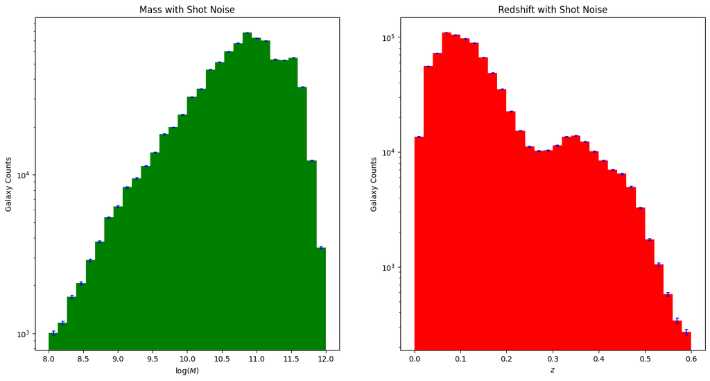

```python
# Calculate the shot noise in each histogram bin
p_err = p_counts / np.sqrt(p_counts)
z_err = z_counts / np.sqrt(z_counts)

# Calculate the bin centres (these are linearly spaced)
p_centres = np.zeros(nBins)
z_centres = np.zeros(nBins)
for i in range(0, nBins):
    p_centres[i] = (p_bins[i] + p_bins[i + 1]) / 2
    z_centres[i] = (z_bins[i] + z_bins[i + 1]) / 2
# End of for loop

# Recreate the plot with shot noise included
fig = plt.figure(figsize = (16, 8))
gs = fig.add_gridspec(1, 2, wspace = 0.2, hspace = 0.0)

# Add an axes to the plot
ax1 = fig.add_subplot(gs[0, 0])
ax2 = fig.add_subplot(gs[0, 1])

# Add the titles to the plot
ax1.title.set_text('Mass with Shot Noise')
ax2.title.set_text('Redshift with Shot Noise')

# Add the histograms to the plot
ax1.hist(p_vec, bins = p_bins, density = False, color = 'green', zorder = 1)
ax1.errorbar(p_centres, p_counts, color = 'blue', yerr = p_err, fmt = ' ', marker = ',', capsize = 2, zorder = 2)
ax2.hist(z_vec, bins = z_bins, density = False, color = 'red')
ax2.errorbar(z_centres, z_counts, color = 'blue', yerr = z_err, fmt = ' ', marker = ',', capsize = 2, zorder = 2)

# Set the plot axes
ax1.set_xlabel('$\log(M)$')
ax1.set_ylabel('Galaxy Counts')
ax1.set_yscale('log')
ax2.set_xlabel('$z$')
ax2.set_ylabel('Galaxy Counts')
ax2.set_yscale('log')

plt.show()
```

Now split the data into N subsets and compute the jackknife covarinace of the histogram bins.

- How does it compare to the analytic errors?
- Are the bins independent?
- What happens if you make N very large or very small?

```python
# Define a function to calculate the Jackknife covariance
def Jack_Cov(vector, N, nBins, bin_edges):

    # Split the array into our Jackknife subvolumes
    jack_sub = np.array_split(vector, N)

    # Setup a matrix to store our histogram bins for each Jackknife subsample
    jack_hist = np.zeros((N, nBins))

    # Loop over each of our Jackknife subvolumes
    for k in range(0, N):

        # Get the rest of the data with the kth subvolume omitted
        jack_list = []
        for l in range(0, N):
            if (l != k):
                jack_list.append(jack_sub[l])
            # End of if
        # End of for loop

        # Collapse the list into a single vector
        jack_vec = np.concatenate(jack_list)

        # Compute the histogram for this set of subvolumes
        jack_hist[k] = np.histogram(jack_vec, bins = bin_edges)[0]

    # End of for loop

    # Compute the Jackknife covariance matrix for the histogram bins
    # Note: The numpy version to compute the covariance has a different
    #       normalization than what we need for Jackknife
    #       In numpy, the normalization factor is 1/(N - 1)
    cov_jack = ((N - 1)**2 / N) * np.cov(jack_hist.T)

    # Return the covariance matrix
    return cov_jack

# End of function definition
```

```python
# Here we are only going to calculate errors for the model parameter
# and not redshift as well

# Set a seed so that we obtain the same random sample each time
np.random.seed(20726114)

# Create a copy of the original array and shuffle it
p_vec2 = p_vec.copy()
np.random.shuffle(p_vec2)
```

```python
# Set the number of Jackknife subsets to use
# Note: These need to be of equal "volume"
N_vec = np.array([2, 5, 10, 20, 50, 100, 200, 500, 1000, 2000, 5000, 10000, 20000])

# Set a vector to store the errors as a function of N
jack_err = np.zeros((len(N_vec), nBins))

# Loop over each N
for n in range(0, len(N_vec)):

    # Calculate the covariance of the histogram bins
    cov_jack = Jack_Cov(p_vec2, N_vec[n], nBins, bin_edges)

    # Get the errors from the covariance matrix
    jack_err[n] = np.sqrt(np.diagonal(cov_jack))

    # Store the covariance matrix if N = 200
    if (N_vec[n] == 200):
        cov_jack_200 = cov_jack
    # End of if

# End of for loop
```

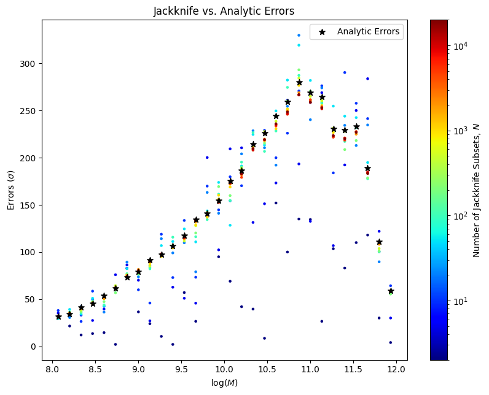

```python
# Plot of the Jackknife errors for all bins as a function of Jackknife subsets

# Create the figure
fig = plt.figure(figsize = (9.6, 7.2))
ax = plt.subplot(1, 1, 1)

# Setup a colourbar that shows the value of N
norm = mcolors.LogNorm(vmin = min(N_vec), vmax = max(N_vec))
cmap = plt.cm.ScalarMappable(norm = norm, cmap = plt.cm.jet)

# Set the title
ax.title.set_text('Jackknife vs. Analytic Errors')

# Loop over each value of N
for n in range(0, len(N_vec)):
    ax.scatter(p_centres, jack_err[n], c = cmap.to_rgba(np.ones(nBins) * N_vec[n]), s = 5, zorder = 1)
# End of for loop

# Add the analytic errors
ax.scatter(p_centres, p_err, c = 'black', s = 50, marker = '*', zorder = 2, label = 'Analytic Errors')

# Set the plot axes
ax.set_xlabel('$\log(M)$')
ax.set_ylabel('Errors ($\\sigma$)')
ax.legend()

# Create the colourbar for the bins
cbar = fig.colorbar(cmap, ax = ax)
cbar.ax.set_ylabel('Number of Jackknife Subsets, $N$')

plt.show()
```

The plot above shows how the Jackknife errors for each histogram bin compare with the analytic errors. These were calculated by taking the square root of the variances along the diagonal of the Jackknife covariance matrix. The colourbar shows how these errors compare when considering different numbers of subsets, $N$, to split our data into for calculating the covariance. The analytic errors are shown as the black stars.

In general, the Jackknife errors compare pretty well with the analytic errors. How well the Jackknife errors match the analytic errors depends on the number of subsets the data is split into. Considering all mass bins, the optimal number of subsets to best match the analytic errors appears to be $\sim 200 - 1000$.

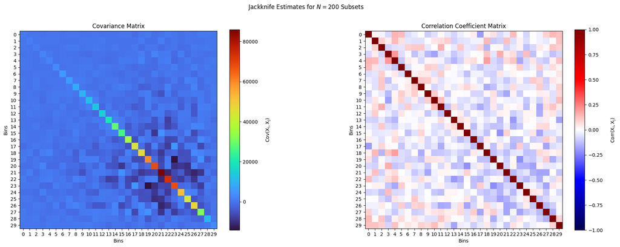

```python
# Calculate the correlation coefficients from the covariance matrix
corr_jack_200 = np.zeros(cov_jack_200.shape)
for i in range(0, corr_jack_200.shape[0]):
    for j in range(0, corr_jack_200.shape[1]):
        corr_jack_200[i, j] = cov_jack_200[i, j] / np.sqrt(cov_jack_200[i, i] * cov_jack_200[j, j])
    # End of for loop
# End of for loop

# Plot of the covariance matrix for N = 200 Jackknife subsets

fig = plt.figure(figsize = (22, 7.5))
gs = fig.add_gridspec(1, 2, wspace = 0.4, hspace = 0.0)

fig.suptitle('Jackknife Estimates for $N = 200$ Subsets')

ax1 = fig.add_subplot(gs[0, 0])
ax2 = fig.add_subplot(gs[0, 1])

ax1.title.set_text('Covariance Matrix')
ax2.title.set_text('Correlation Coefficient Matrix')
im1 = ax1.imshow(cov_jack_200, interpolation = 'nearest', origin = 'upper', cmap = 'turbo')
im2 = ax2.imshow(corr_jack_200, interpolation = 'nearest', origin = 'upper', vmin = -1.0, vmax = 1.0, cmap = 'seismic')

# Set the tick labels
ax1.set_xticks(list(range(0, nBins)))
ax1.set_yticks(list(range(0, nBins)))
ax2.set_xticks(list(range(0, nBins)))
ax2.set_yticks(list(range(0, nBins)))

# Set the axis labels
ax1.set_xlabel('Bins')
ax1.set_ylabel('Bins')
ax2.set_xlabel('Bins')
ax2.set_ylabel('Bins')

# Add a colourbar
cbar1 = fig.colorbar(im1, orientation = 'vertical')
cbar1.ax.set_ylabel('$\\rm{Cov}(X_i, X_j)$', rotation = 90, labelpad = 15)
cbar2 = fig.colorbar(im2, orientation = 'vertical')
cbar2.ax.set_ylabel('$\\rm{Corr}(X_i, X_j)$', rotation = 90, labelpad = 15)

plt.show()
```

The above plot shows the covariance and correlations between each of the histogram bins when the Jackknife procedure uses $200$ subsets. For two variables (or bins in this case) to be independent, their covariance and correlation coefficients must be zero. The result above clearly demonstrates that the mass bins are not independent since they have non-zero correlation coefficients. In many cases, the correlation coefficient between the bins is $|\rho| > 0.1$.

Now repeat this excercise, replacing the histogram with a calculation of the mean stellar mass as a function of redshift (i.e. split the data into redshift bins, and compute the mean mass in each).

```python
# Define a function to determine the mean stellar mass
# and standard error of the mean for each redshift bin
def MeanStellar(z_vec, m_vec, nBins, zbin_edges):

    # Split the data into bins by redshift
    digitized = np.digitize(z_vec, zbin_edges, right = False)

    # Get the stellar mass data for each redshift bin
    binned_data = [m_vec[digitized == i] for i in range(1, nBins + 1)]

    # Set vectors to store the mean mass, number of galaxies, and
    # standard error in each redshift bin
    mean_mass_vec = np.zeros(nBins)
    Ngal_vec = np.zeros(nBins)
    stderr_vec = np.zeros(nBins)

    # Loop over each redshift bin
    for i in range(0, nBins):

        # Calculate the mean mass in the bin
        mean_mass_vec[i] = np.mean(10**binned_data[i])

        # Calculate the number of galaxies in the bin
        Ngal_vec[i] = binned_data[i].shape[0]

        # Calculate the standard error in the bin
        stderr_vec[i] = np.sqrt( np.var(10**binned_data[i], ddof = 1) / Ngal_vec[i] )

    # End of for loop

    # Return the desired outputs
    return (mean_mass_vec, Ngal_vec, stderr_vec)

# End of function definition
```

```python
# Set the number of redshift bins we want
znBins = 30

# Set the ranges for the redshifts
zL, zR = 0.0, 0.6

# Calculate the bin spacing
zbin_size = (zR - zL) / znBins

# Calculate the bin edges
zbin_edges = np.arange(zL, zR + zbin_size, zbin_size)

# Extract the redshift information from the input catalogue
z_vec = in_cat['redshift'].values.T

# Extract the stellar mass information from the output catalogue
# Note: We are assuming the true parameter value is the 50% percentile
m_vec = out_cat['lmass50_all'].values.T

# Remove values outside the desired ranges
# Note: The input and output catalogues are both sorted by Id
#       so these vectors are in the same order
filter = (zL <= z_vec) & (z_vec <= zR)
z_vec = z_vec[filter]
m_vec = m_vec[filter]

# Calculate the mean stellar mass and standard error of the mean vs. redshift
(mean_mass_vec, Ngal_vec, stderr_vec) = MeanStellar(z_vec, m_vec, znBins, zbin_edges)
```

Use Jackknife to get the errors. How do these compare with the standard error of the mean?

Note: The standard error of the mean can be calculated as $\sigma_\bar{M} = \frac{\sigma}{\sqrt{N}}$, where $\sigma$ is the standard deviation of the stellar mass in each redshift bin and $N$ is the number of galaxies considered in each bin.

```python
# Define a function to calculate the Jackknife errors
def Jack_Std(N, z_vec, m_vec, nBins, bin_edges):

    # Split the array into our Jackknife subvolumes
    jack_sub_z = np.array_split(z_vec, N)
    jack_sub_m = np.array_split(m_vec, N)

    # Setup a matrix to store our redshift bins for each Jackknife subsample
    jack_hist = np.zeros((N, nBins))

    # Loop over each of our Jackknife subvolumes
    for k in range(0, N):

        # Get the rest of the data with the kth subvolume omitted
        jack_list_z = []
        jack_list_m = []
        for l in range(0, N):
            if (l != k):
                jack_list_z.append(jack_sub_z[l])
                jack_list_m.append(jack_sub_m[l])
            # End of if
        # End of for loop

        # Collapse the lists into single vectors
        jack_vec_z = np.concatenate(jack_list_z)
        jack_vec_m = np.concatenate(jack_list_m)

        # Compute the mean stellar mass vs. redshift for this set of subvolumes
        (jack_hist[k], _, _) = MeanStellar(jack_vec_z, jack_vec_m, nBins, bin_edges)

    # End of for loop

    # Compute the Jackknife covariance matrix for the redshift bins
    # Note: The numpy version to compute the covariance has a different
    #       normalization than what we need for Jackknife
    #       In numpy, the normalization factor is 1/(N - 1)
    cov_jack = ((N - 1)**2 / N) * np.cov(jack_hist.T)

    # Get and return the errors from the covariance matrix
    return np.sqrt(np.diagonal(cov_jack))

# End of function definition
```

```python
# Set the number of Jackknife subsets to use
# Note: These need to be of equal "volume"
N_vec = np.array([2, 5, 10, 20, 50, 100, 200, 500, 1000, 2000, 5000])

# Set a vector to store the errors as a function of N
jack_std = np.zeros((len(N_vec), znBins))

# Loop over each N
for n in range(0, len(N_vec)):

    # Calculate the Jackknife error for each redshift bin
    jack_std[n] = Jack_Std(N_vec[n], z_vec, m_vec, znBins, zbin_edges)

# End of for loop
```

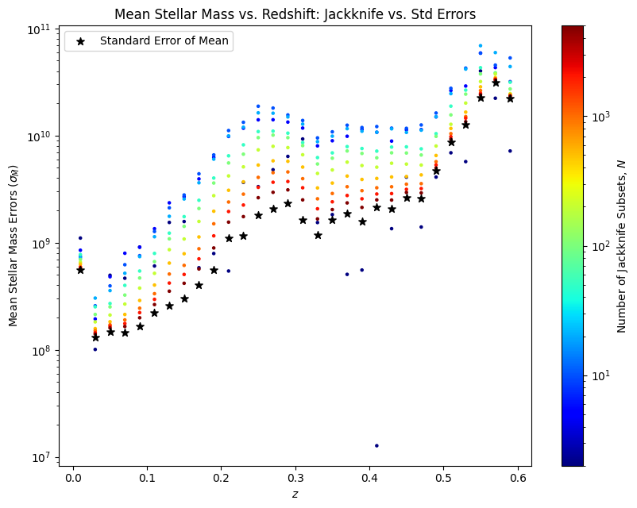

```python
# Calculate the bin centres (these are linearly spaced)
z_centres = np.zeros(znBins)
for i in range(0, znBins):
    z_centres[i] = (zbin_edges[i] + zbin_edges[i + 1]) / 2
# End of for loop

# Plot of the Jackknife errors for all redshift bins as a function of Jackknife subsets

# Create the figure
fig = plt.figure(figsize = (9.6, 7.2))
ax = plt.subplot(1, 1, 1)

# Setup a colourbar that shows the value of N
norm = mcolors.LogNorm(vmin = min(N_vec), vmax = max(N_vec))
cmap = plt.cm.ScalarMappable(norm = norm, cmap = plt.cm.jet)

# Set the title
ax.title.set_text('Mean Stellar Mass vs. Redshift: Jackknife vs. Std Errors')

# Loop over each value of N
for n in range(0, len(N_vec)):
    ax.scatter(z_centres, jack_std[n], c = cmap.to_rgba(np.ones(znBins) * N_vec[n]), s = 5, zorder = 1)
# End of for loop

# Add the analytic errors
ax.scatter(z_centres, stderr_vec, c = 'black', s = 50, marker = '*', zorder = 2, label = 'Standard Error of Mean')

# Set the plot axes
ax.set_xlabel('$z$')
ax.set_ylabel('Mean Stellar Mass Errors ($\\sigma_\\bar{M}$)')
ax.set_yscale('log')
ax.legend()

# Create the colourbar for the bins
cbar = fig.colorbar(cmap, ax = ax)
cbar.ax.set_ylabel('Number of Jackknife Subsets, $N$')

plt.show()
```

The plot above shows how the Jackknife estimates for the error in the mean stellar mass vs. redshift compares with the standard error of the mean. These again were calculated by taking the square root of the diagonal entries of the Jackknife covariance matrix. Each of the diagonal entries is an estimate of the variance in the mean stellar mass in one of the redshift bins. The colourbar shows how these errors compare when considering different numbers of subsets to split our data into for calculating the covariance. The standard error of the mean is shown as black stars.

Our results show that in general, our Jackknife errors tend to be more conservative/larger than the standard error of the mean. As the number of Jackknife subsets increases, the Jackknife error estimates tend towards the standard errors. This is because as $N$ increases, the number of mass estimates we have in each redshift bin increases as well (i.e., we have $N$ in each bin). For a given redshift bin, as $N$ increases, the average difference between each mean stellar mass measurement and the average mean stellar mass in the bin becomes smaller, resulting in a lower standard deviation. If $N$ was too large, then for a given redshift bin, each mean stellar mass measurement would tend towards the average of all the mean stellar mass measurements in the bin, which should result in a Jackknife error estimate lower than the standard error of the mean.